# Exploratory Data

## By: Shashwat Singh Mann

### Overview

Prosper Marketplace, Inc. is a California-based p2p lending industry. Prosper maintains a full public database of all loans issued through its marketplace on its website. This database and all market statistics can be accessed and queried for analysis of loan performance over time. An interface to run complex performance queries is supported and allows investors (and the public) to look into the performance of any subset of loans over whatever time period they choose.

### Wrangling

```python
# import all packages and set plots to be embedded inline
import numpy as np
import pandas as pd
import matplotlib.pyplot as plt
%matplotlib inline
import seaborn as sb
from jupyterthemes import jtplot
jtplot.style(theme='onedork')
import glob
import os
import datetime
```

```python
#load the data
df = pd.read_csv('prosperLoanData.csv',sep=',', encoding='latin-1',error_bad_lines=False, index_col=False, dtype='unicode')
```

```python
#extracting first five data of the dataframe to get a better idea to work on it
df.head()
```

|  | ListingKey | ListingNumber | ListingCreationDate | CreditGrade | Term | LoanStatus | ClosedDate | BorrowerAPR | BorrowerRate | LenderYield | ... | LP_ServiceFees | LP_CollectionFees | LP_GrossPrincipalLoss | LP_NetPrincipalLoss | LP_NonPrincipalRecoverypayments | PercentFunded | Recommendations | InvestmentFromFriendsCount | InvestmentFromFriendsAmount | Investors |
| --- | --- | --- | --- | --- | --- | --- | --- | --- | --- | --- | --- | --- | --- | --- | --- | --- | --- | --- | --- | --- | --- |
| 0 | 1021339766868145413AB3B | 193129 | 2007-08-26 19:09:29.263000000 | C | 36 | Completed | 2009-08-14 00:00:00 | .165160 | .158000 | .138000 | ... | -133.180000 | .000000 | .000000 | .000000 | .000000 | 1.000000 | 0 | 0 | .000000 | 258 |
| 1 | 10273602499503308B223C1 | 1209647 | 2014-02-27 08:28:07.900000000 | NaN | 36 | Current | NaN | .120160 | .092000 | .082000 | ... | .000000 | .000000 | .000000 | .000000 | .000000 | 1.000000 | 0 | 0 | .000000 | 1 |
| 2 | 0EE9337825851032864889A | 81716 | 2007-01-05 15:00:47.090000000 | HR | 36 | Completed | 2009-12-17 00:00:00 | .282690 | .275000 | .240000 | ... | -24.200000 | .000000 | .000000 | .000000 | .000000 | 1.000000 | 0 | 0 | .000000 | 41 |
| 3 | 0EF5356002482715299901A | 658116 | 2012-10-22 11:02:35.010000000 | NaN | 36 | Current | NaN | .125280 | .097400 | .087400 | ... | -108.010000 | .000000 | .000000 | .000000 | .000000 | 1.000000 | 0 | 0 | .000000 | 158 |
| 4 | 0F023589499656230C5E3E2 | 909464 | 2013-09-14 18:38:39.097000000 | NaN | 36 | Current | NaN | .246140 | .208500 | .198500 | ... | -60.270000 | .000000 | .000000 | .000000 | .000000 | 1.000000 | 0 | 0 | .000000 | 20 |

5 rows × 81 columns

```python
# to look at all the columns at once so that I could exctract the ones which are necessary to me
pd.set_option('display.max_columns', None)
```

```python
# checking it again
df.head()
```

|  | ListingKey | ListingNumber | ListingCreationDate | CreditGrade | Term | LoanStatus | ClosedDate | BorrowerAPR | BorrowerRate | LenderYield | EstimatedEffectiveYield | EstimatedLoss | EstimatedReturn | ProsperRating (numeric) | ProsperRating (Alpha) | ProsperScore | ListingCategory (numeric) | BorrowerState | Occupation | EmploymentStatus | EmploymentStatusDuration | IsBorrowerHomeowner | CurrentlyInGroup | GroupKey | DateCreditPulled | CreditScoreRangeLower | CreditScoreRangeUpper | FirstRecordedCreditLine | CurrentCreditLines | … |
| --- | --- | --- | --- | --- | --- | --- | --- | --- | --- | --- | --- | --- | --- | --- | --- | --- | --- | --- | --- | --- | --- | --- | --- | --- | --- | --- | --- | --- | --- | --- |
| 0 | 1021339766868145413AB3B | 193129 | 2007-08-26 19:09:29.263000000 | C | 36 | Completed | 2009-08-14 00:00:00 | .165160 | .158000 | .138000 | NaN | NaN | NaN | NaN | NaN | NaN | 0 | CO | Other | Self-employed | 2 | True | True | NaN | 2007-08-26 18:41:46.780000000 | 640 | 659 | 2001-10-11 00:00:00 | 5 | … |
| 1 | 10273602499503308B223C1 | 1209647 | 2014-02-27 08:28:07.900000000 | NaN | 36 | Current | NaN | .120160 | .092000 | .082000 | .079600 | .024900 | .054700 | 6 | A | 7.000000 | 2 | CO | Professional | Employed | 44 | False | False | NaN | 2014-02-27 08:28:14 | 680 | 699 | 1996-03-18 00:00:00 | 14 | … |
| 2 | 0EE9337825851032864889A | 81716 | 2007-01-05 15:00:47.090000000 | HR | 36 | Completed | 2009-12-17 00:00:00 | .282690 | .275000 | .240000 | NaN | NaN | NaN | NaN | NaN | NaN | 0 | GA | Other | Not available | NaN | False | True | 783C3371218786870A73D20 | 2007-01-02 14:09:10.060000000 | 480 | 499 | 2002-07-27 00:00:00 | NaN | … |
| 3 | 0EF5356002482715299901A | 658116 | 2012-10-22 11:02:35.010000000 | NaN | 36 | Current | NaN | .125280 | .097400 | .087400 | .084900 | .024900 | .060000 | 6 | A | 9.000000 | 16 | GA | Skilled Labor | Employed | 113 | True | False | NaN | 2012-10-22 11:02:32 | 800 | 819 | 1983-02-28 00:00:00 | 5 | … |
| 4 | 0F023589499656230C5E3E2 | 909464 | 2013-09-14 18:38:39.097000000 | NaN | 36 | Current | NaN | .246140 | .208500 | .198500 | .183160 | .092500 | .090660 | 3 | D | 4.000000 | 2 | MN | Executive | Employed | 44 | True | False | NaN | 2013-09-14 18:38:44 | 680 | 699 | 2004-02-20 00:00:00 | 19 | … |

This data set contains 113,937 loans with 81 variables on each loan, including loan amount, borrower rate (or interest rate), current loan status, borrower income, and many others.

```python
# rows will be the total number of loans and columns will be its variables
df.shape
```

```
(113937, 81)
```

Filtering Columns so make it simpler

```python
# extracting out the important columns
df = df[['LoanOriginalAmount', 'LoanStatus', 'BorrowerAPR', 'BorrowerRate', 'IncomeRange', 'Term', 'ProsperRating (Alpha)', 'EmploymentStatus', 'EmploymentStatusDuration']]
```

```python
# extracting first five data of the dataframe to get a better idea to work on it
df.head()
```

|  | LoanOriginalAmount | LoanStatus | BorrowerAPR | BorrowerRate | IncomeRange | Term | ProsperRating (Alpha) | EmploymentStatus | EmploymentStatusDuration |
| --- | --- | --- | --- | --- | --- | --- | --- | --- | --- |
| 0 | 9425 | Completed | .165160 | .158000 | $25,000-49,999 | 36 | NaN | Self-employed | 2 |
| 1 | 10000 | Current | .120160 | .092000 | $50,000-74,999 | 36 | A | Employed | 44 |
| 2 | 3001 | Completed | .282690 | .275000 | Not displayed | 36 | NaN | Not available | NaN |
| 3 | 10000 | Current | .125280 | .097400 | $25,000-49,999 | 36 | A | Employed | 113 |
| 4 | 15000 | Current | .246140 | .208500 | $100,000+ | 36 | D | Employed | 44 |

```python
# check unique values in order to understand the column content better

def show_unique_values(df, var_list):
    for var in var_list:
        print(var, ' Unique Values:\n', df[var].unique(), '\n')

show_unique_values(df, df.columns.tolist())
```

```
LoanOriginalAmount  Unique Values:
 ['9425' '10000' '3001' ... '17669' '19432' '4292']

LoanStatus  Unique Values:
 ['Completed' 'Current' 'Past Due (1-15 days)' 'Defaulted' 'Chargedoff'
 'Past Due (16-30 days)' 'Cancelled' 'Past Due (61-90 days)'
 'Past Due (31-60 days)' 'Past Due (91-120 days)' 'FinalPaymentInProgress'
 'Past Due (>120 days)']

BorrowerAPR  Unique Values:
 ['.165160' '.120160' '.282690' ... '.226740' '.347700' '.195430']

BorrowerRate  Unique Values:
 ['.158000' '.092000' '.275000' ... '.203700' '.230900' '.073900']

IncomeRange  Unique Values:
 ['$25,000-49,999' '$50,000-74,999' 'Not displayed' '$100,000+'
 '$75,000-99,999' '$1-24,999' 'Not employed' '$0']

Term  Unique Values:
 ['36' '60' '12']

ProsperRating (Alpha)  Unique Values:
 [nan 'A' 'D' 'B' 'E' 'C' 'AA' 'HR']

EmploymentStatus  Unique Values:
 ['Self-employed' 'Employed' 'Not available' 'Full-time' 'Other' nan
 'Not employed' 'Part-time' 'Retired']

EmploymentStatusDuration  Unique Values:
 ['2' '44' nan '113' '82' '172' '103' '269' '300' '19' '1' '98' '35' '121'
 '133' '179' '18' '175' '36' '68' '3' '91' '15' '25' '10' '48' '16' '7'
 '426' '55' '112' '361' '539' '276' '76' '32' '28' '90' '145' '43' '0'
 '209' '61' '51' '155' '89' '80' '195' '427' '70' '34' '12' '37' '141'
 '84' '213' '72' '21' '173' '47' '117' '93' '131' '127' '5' '166' '33'
 '42' '30' '189' '192' '193' '94' '29' '27' '279' '24' '23' '56' '130'
 '232' '125' '180' '8' '107' '52' '13' '551' '126' '111' '20' '249' '39'
 '395' '259' '124' '4' '57' '265' '83' '22' '198' '201' '109' '200' '79'
 '9' '247' '281' '381' '108' '14' '87' '120' '110' '71' '41' '158' '211'
 '54' '60' '67' '169' '311' '187' '116' '26' '106' '134' '114' '75' '178'
```

[output cut: 25 more lines]

[output not shown]

## Cleaning

Finding null values in the dataframe

```python
# checking null values
df.isnull()
```

|  | LoanOriginalAmount | LoanStatus | BorrowerAPR | BorrowerRate | IncomeRange | Term | ProsperRating (Alpha) | EmploymentStatus | EmploymentStatusDuration |
| --- | --- | --- | --- | --- | --- | --- | --- | --- | --- |
| 0 | False | False | False | False | False | False | True | False | False |
| 1 | False | False | False | False | False | False | False | False | False |
| 2 | False | False | False | False | False | False | True | False | True |
| 3 | False | False | False | False | False | False | False | False | False |
| 4 | False | False | False | False | False | False | False | False | False |
| ... | ... | ... | ... | ... | ... | ... | ... | ... | ... |
| 113932 | False | False | False | False | False | False | False | False | False |
| 113933 | False | False | False | False | False | False | False | False | False |
| 113934 | False | False | False | False | False | False | False | False | False |
| 113935 | False | False | False | False | False | False | False | False | False |
| 113936 | False | False | False | False | False | False | False | False | False |

113937 rows × 9 columns

```python
# checking null values in LoanOriginalAmount
df[df['LoanOriginalAmount'].isnull()]
```

|  | LoanOriginalAmount | LoanStatus | BorrowerAPR | BorrowerRate | IncomeRange | Term | ProsperRating (Alpha) | EmploymentStatus | EmploymentStatusDuration |
| --- | --- | --- | --- | --- | --- | --- | --- | --- | --- |

```python
# checking null values in BorrowerAPR
df[df['BorrowerAPR'].isnull()]
```

|  | LoanOriginalAmount | LoanStatus | BorrowerAPR | BorrowerRate | IncomeRange | Term | ProsperRating (Alpha) | EmploymentStatus | EmploymentStatusDuration |
| --- | --- | --- | --- | --- | --- | --- | --- | --- | --- |
| 2543 | 4200 | Completed | NaN | .100000 | Not displayed | 36 | NaN | NaN | NaN |
| 14632 | 2620 | Completed | NaN | .065000 | Not displayed | 36 | NaN | NaN | NaN |
| 25166 | 1000 | Completed | NaN | .043500 | Not displayed | 36 | NaN | NaN | NaN |
| 25330 | 1500 | Completed | NaN | .063950 | Not displayed | 36 | NaN | NaN | NaN |
| 29773 | 3000 | Completed | NaN | .060000 | Not displayed | 36 | NaN | NaN | NaN |
| 39870 | 15000 | Completed | NaN | .120000 | Not displayed | 36 | NaN | NaN | NaN |
| 43587 | 5000 | Completed | NaN | .085000 | Not displayed | 36 | NaN | NaN | NaN |
| 62297 | 1000 | Completed | NaN | .170000 | Not displayed | 36 | NaN | NaN | NaN |
| 71280 | 10000 | Completed | NaN | .090000 | Not displayed | 36 | NaN | NaN | NaN |
| 71875 | 3000 | Completed | NaN | .070000 | Not displayed | 36 | NaN | NaN | NaN |
| 73945 | 2500 | Completed | NaN | .250000 | Not displayed | 36 | NaN | NaN | NaN |
| 74114 | 1000 | Completed | NaN | .060000 | Not displayed | 36 | NaN | NaN | NaN |
| 75710 | 4000 | Completed | NaN | .100000 | Not displayed | 36 | NaN | NaN | NaN |
| 78414 | 2000 | Completed | NaN | .130000 | Not displayed | 36 | NaN | NaN | NaN |
| 80369 | 2689 | Completed | NaN | .065000 | Not displayed | 36 | NaN | NaN | NaN |
| 81848 | 4000 | Completed | NaN | .130000 | Not displayed | 36 | NaN | NaN | NaN |
| 90598 | 1000 | Completed | NaN | .120000 | Not displayed | 36 | NaN | NaN | NaN |
| 92516 | 3500 | Completed | NaN | .070000 | Not displayed | 36 | NaN | NaN | NaN |
| 103509 | 8998 | Completed | NaN | .094500 | Not displayed | 36 | NaN | NaN | NaN |
| 105925 | 5000 | Completed | NaN | .085000 | Not displayed | 36 | NaN | NaN | NaN |
| 106465 | 4800 | Completed | NaN | .090000 | Not displayed | 36 | NaN | NaN | NaN |
| 106735 | 1500 | Completed | NaN | .059500 | Not displayed | 36 | NaN | NaN | NaN |
| 109027 | 3000 | Completed | NaN | .060000 | Not displayed | 36 | NaN | NaN | NaN |
| 111607 | 3000 | Completed | NaN | .065000 | Not displayed | 36 | NaN | NaN | NaN |
| 113921 | 1000 | Completed | NaN | .040000 | Not displayed | 36 | NaN | NaN | NaN |

```python
# checking null values in ProsperRating (Alpha)
df[df['ProsperRating (Alpha)'].isnull()]
```

|  | LoanOriginalAmount | LoanStatus | BorrowerAPR | BorrowerRate | IncomeRange | Term | ProsperRating (Alpha) | EmploymentStatus | EmploymentStatusDuration |
| --- | --- | --- | --- | --- | --- | --- | --- | --- | --- |
| 0 | 9425 | Completed | .165160 | .158000 | $25,000-49,999 | 36 | NaN | Self-employed | 2 |
| 2 | 3001 | Completed | .282690 | .275000 | Not displayed | 36 | NaN | Not available | NaN |
| 11 | 1000 | Completed | .150330 | .132500 | $1-24,999 | 36 | NaN | Full-time | 19 |
| 17 | 10000 | Chargedoff | .132020 | .125000 | Not displayed | 36 | NaN | Not available | NaN |
| 21 | 3000 | Completed | .214880 | .207500 | $25,000-49,999 | 36 | NaN | Full-time | 36 |
| ... | ... | ... | ... | ... | ... | ... | ... | ... | ... |
| 113921 | 1000 | Completed | NaN | .040000 | Not displayed | 36 | NaN | NaN | NaN |
| 113922 | 5000 | Completed | .150940 | .129500 | $50,000-74,999 | 36 | NaN | Full-time | 115 |
| 113923 | 8000 | Completed | .223780 | .208900 | $25,000-49,999 | 36 | NaN | Full-time | 83 |
| 113926 | 3000 | Defaulted | .297760 | .290000 | Not displayed | 36 | NaN | Not available | NaN |
| 113927 | 4292 | Completed | .074690 | .067900 | $100,000+ | 36 | NaN | Full-time | 69 |

29084 rows × 9 columns

```python
# deleting all the rows where ProsperRating (Alpha) has a null value
df = df[df['ProsperRating (Alpha)'].notnull()]
```

```python
# checking null values in EmploymentStatusDuration
df[df['EmploymentStatusDuration'].isnull()]
```

|  | LoanOriginalAmount | LoanStatus | BorrowerAPR | BorrowerRate | IncomeRange | Term | ProsperRating (Alpha) | EmploymentStatus | EmploymentStatusDuration |
| --- | --- | --- | --- | --- | --- | --- | --- | --- | --- |
| 11237 | 5000 | Chargedoff | .374530 | .350000 | $25,000-49,999 | 36 | HR | Full-time | NaN |
| 12462 | 4000 | Current | .357970 | .317700 | $50,000-74,999 | 36 | HR | Full-time | NaN |
| 18728 | 15000 | Current | .210250 | .173400 | $100,000+ | 36 | C | Full-time | NaN |
| 25077 | 3500 | Current | .266810 | .228700 | $50,000-74,999 | 36 | D | Full-time | NaN |
| 26753 | 1500 | Completed | .223900 | .199000 | $1-24,999 | 36 | C | Full-time | NaN |
| 27163 | 5000 | Completed | .248220 | .225500 | $25,000-49,999 | 36 | C | Self-employed | NaN |
| 29952 | 5000 | Completed | .266810 | .228700 | $25,000-49,999 | 36 | D | Self-employed | NaN |
| 30117 | 2500 | Completed | .104360 | .083500 | $50,000-74,999 | 36 | A | Full-time | NaN |
| 31660 | 1500 | Completed | .125390 | .121900 | $50,000-74,999 | 36 | AA | Full-time | NaN |
| 56750 | 10000 | Current | .246140 | .208500 | $75,000-99,999 | 36 | D | Other | NaN |
| 74308 | 3500 | Completed | .310530 | .275000 | $100,000+ | 36 | D | Full-time | NaN |
| 74424 | 2000 | Current | .285440 | .246900 | $25,000-49,999 | 36 | D | Other | NaN |
| 78900 | 15000 | Current | .191440 | .155000 | $25,000-49,999 | 36 | B | Other | NaN |
| 82503 | 4000 | Current | .158330 | .129900 | $25,000-49,999 | 36 | A | Other | NaN |
| 83241 | 4000 | Current | .353560 | .313400 | $25,000-49,999 | 36 | HR | Other | NaN |
| 84254 | 20000 | Current | .162940 | .139900 | $75,000-99,999 | 60 | B | Other | NaN |
| 98944 | 1500 | Completed | .223900 | .199000 | $25,000-49,999 | 36 | C | Full-time | NaN |
| 104632 | 25000 | Current | .229080 | .204500 | $100,000+ | 60 | C | Employed | NaN |
| 106358 | 2500 | Chargedoff | .263950 | .225900 | $1-24,999 | 36 | D | Full-time | NaN |

```python
# deleting all the null values from EmploymentStatusDuration
df = df[df["EmploymentStatusDuration"].notnull()]
```

```python
# replacing the numeric null values with the average of the known values
df = df.fillna(df.mean())
```

```python
# checking the values using head function
df.head()
```

|  | LoanOriginalAmount | LoanStatus | BorrowerAPR | BorrowerRate | IncomeRange | Term | ProsperRating (Alpha) | EmploymentStatus | EmploymentStatusDuration |
| --- | --- | --- | --- | --- | --- | --- | --- | --- | --- |
| 1 | 10000 | Current | .120160 | .092000 | $50,000-74,999 | 36 | A | Employed | 44 |
| 3 | 10000 | Current | .125280 | .097400 | $25,000-49,999 | 36 | A | Employed | 113 |
| 4 | 15000 | Current | .246140 | .208500 | $100,000+ | 36 | D | Employed | 44 |
| 5 | 15000 | Current | .154250 | .131400 | $100,000+ | 60 | B | Employed | 82 |
| 6 | 3000 | Current | .310320 | .271200 | $25,000-49,999 | 36 | E | Employed | 172 |

## Visualization

### Looking at the distribtion of the original loan amount

```python
# converting LoanOriginalAmount to numeric so that could be visualised in graph
df['LoanOriginalAmount'] = pd.to_numeric(df["LoanOriginalAmount"])
```

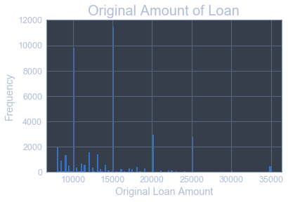

```python
# ploting a histogram
bin_edges = np.arange(8000, df.LoanOriginalAmount.max()+200, 200)
plt.hist(data = df, x = 'LoanOriginalAmount', bins = bin_edges)
plt.xlabel('Original Loan Amount')
plt.ylabel('Frequency')
plt.title("Original Amount of Loan", fontsize = 20);
```

### Loan Status Distribution

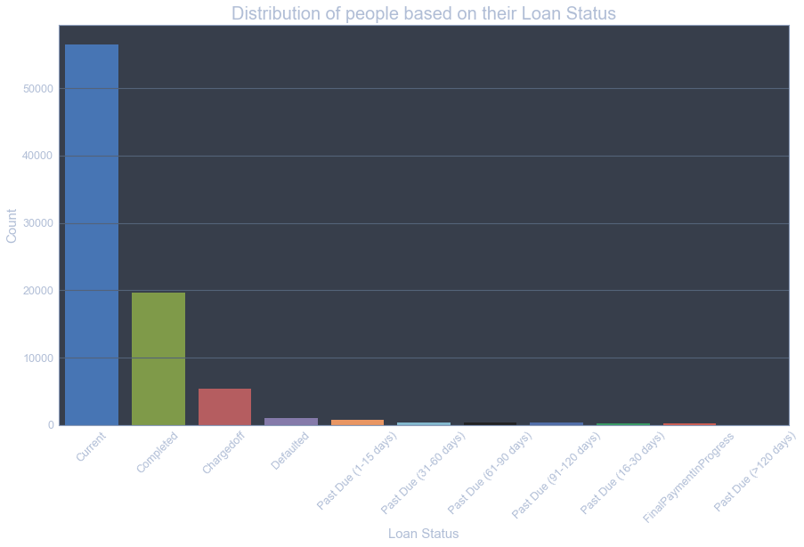

```python
# plotting a graph for that loan status
plt.figure(figsize=(14.70, 8.27))
sb.countplot(data= df, x= 'LoanStatus', order= df.LoanStatus.value_counts().index)
plt.xlabel('Loan Status',fontsize= 15)
plt.ylabel('Count',fontsize= 15)
plt.xticks(rotation=45) # rorating the text at x axis so that it's readable
plt.title('Distribution of people based on their Loan Status',fontsize= 20);
```

From the plot we can see that most of the loan status are current. around 20000 are completed.

### To visualize the loan terms in months

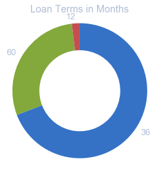

```python
# creating a pie chart
sorted_counts = df['Term'].value_counts()
plt.pie(sorted_counts, labels = sorted_counts.index, startangle = 90, counterclock = False, wedgeprops = {'width' : 0.4});
plt.axis('square');
plt.title("Loan Terms in Months");
```

From the pie chart above, it can be noted that most of the loan term lasts for 3 years and the least number of loan terms lasts for 1 year

### BorrowerAPR

```python
# converting to numeric value
df['BorrowerAPR'] = pd.to_numeric(df["BorrowerAPR"])
```

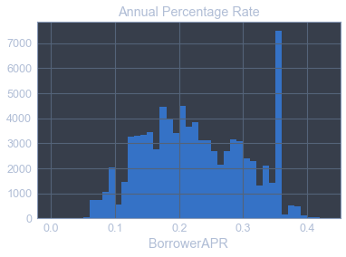

```python
# plotting a histogram for better understanding
bin_edges = np.arange(0, df["BorrowerAPR"].max()+.01, .01)
plt.hist(data = df, x = 'BorrowerAPR', bins = bin_edges)
plt.xlabel('BorrowerAPR');
plt.title("Annual Percentage Rate");
```

### Borrower Interest

```python
# converting to numeric value
df['BorrowerRate'] = pd.to_numeric(df["BorrowerRate"])
```

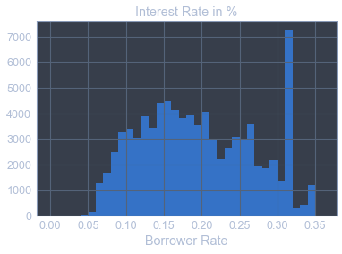

```python
# plotting a histogram for a better understanding
bin_edges = np.arange(0, df["BorrowerRate"].max()+.01, .01)
plt.hist(data = df, x = 'BorrowerRate', bins = bin_edges)
plt.xlabel('Borrower Rate');
plt.title("Interest Rate in %");
```

As expected, the graph of Borrower APR and Rate is the same

### Income Range

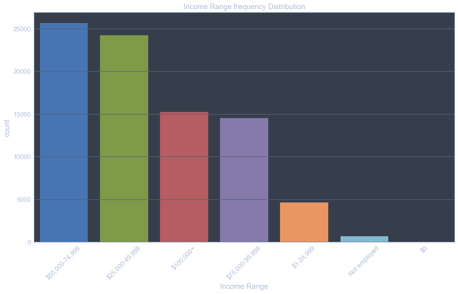

```python
# creating a bar graph of income range
plt.figure(figsize=(14.70, 8.27));
sb.countplot(data = df, x = 'IncomeRange');
plt.title('Income Range frequency Distribution');
plt.xlabel('Income Range');
plt.xticks(rotation=45);
```

The people with the income between $ 50K and $ 75K are the ones get the loans the most. Followed by the ones whose income is between $ 25K and $ 50K. The ones who don't get any loans are the ones who have no income.

### Employment Status Duration

```python
# changing the values of EmploymentStatusDuration to numeric values
df['EmploymentStatusDuration'] = pd.to_numeric(df["EmploymentStatusDuration"])
```

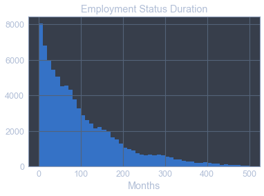

```python
# plotting a histogram to understand the employment duration
bin_edges = np.arange(0, 500+10, 10)
plt.hist(data = df, x = 'EmploymentStatusDuration', bins = bin_edges)
plt.xlabel('Months');
plt.title("Employment Status Duration");
```

Most of the people who apply for the loan are the ones who been in employment for the first 100 months. We can notice the exponential decrease in the number of people taking loans as their employment time increases.

### Employment Status

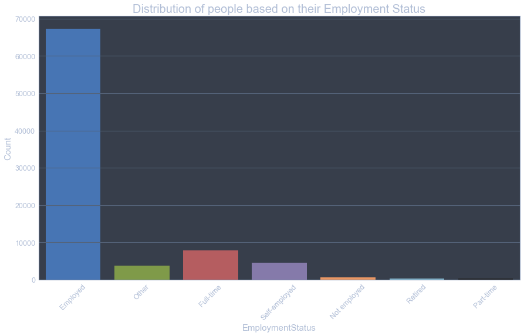

```python
# plotting a bar graph of the employment status
plt.figure(figsize=(14.70, 8.27))
sb.countplot(data= df, x= 'EmploymentStatus')
plt.xlabel('EmploymentStatus',fontsize= 15)
plt.ylabel('Count',fontsize= 15)
plt.xticks(rotation=45) #Made it rotate to 45 degrees so that it is readable
plt.title('Distribution of people based on their Employment Status',fontsize= 20);
```

### Prosper Score

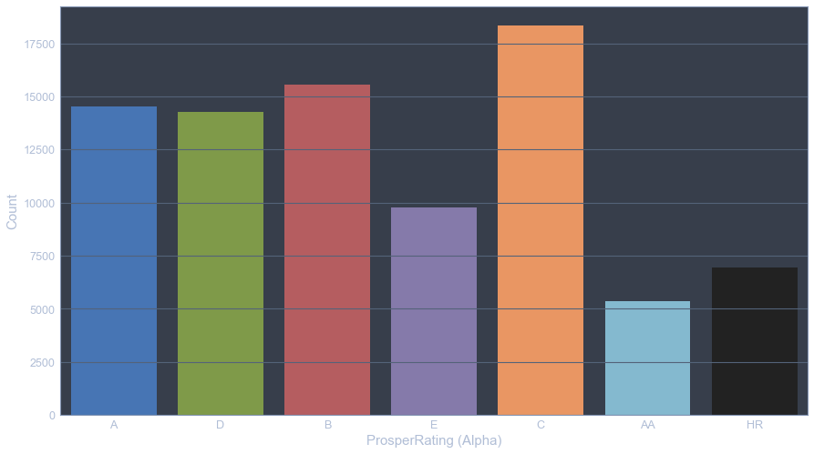

```python
# plotting a bar graph for ProsperRating (Alpha)
plt.figure(figsize=(14.70, 8.27))
sb.countplot(data= df, x= 'ProsperRating (Alpha)')
plt.xlabel('ProsperRating (Alpha)',fontsize= 15)
plt.ylabel('Count',fontsize= 15);
```

Most of the people have a Prosper Rating of C which is an average rating and the Least amount of people have a Prosper Rating of AA, a high rating.

### Relation between the state of Employment, Borrower Rate and Income Range

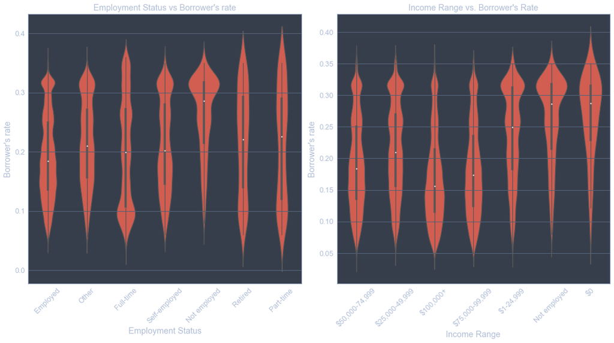

```python
#plotting a violin graph


plt.figure(figsize = [14.70, 8.27])
plt.subplots_adjust(wspace = 0.85)

# violin plot of EmploymentStatus vs BorrowerRate
plt.subplot(1, 2, 1)
sb.violinplot(x = df['EmploymentStatus'], y = df['BorrowerRate'], color = sb.color_palette()[9]);
plt.xlabel('Employment Status');
plt.ylabel('Borrower\'s rate')
plt.title('Employment Status vs Borrower\'s rate');
plt.xticks(rotation = 45);

# violin plot of IncomeRange vs BorrowerRate
plt.subplot(1, 2, 2)
sb.violinplot(x = df['IncomeRange'], y = df['BorrowerRate'], color = sb.color_palette()[9]);
plt.ylabel('Borrower\'s rate');
plt.xlabel('Income Range');
plt.title('Income Range vs. Borrower\'s Rate');
plt.xticks(rotation = 45);

plt.tight_layout();
```

The Unemployed people are the ones who have a higher concentration above the median of Borrower's Rate. It can be notices that it is only the unemployed whose median almost touches 0.3. Other's median is around 0.2. If you look at the income range plot, you will notice that as the income range decreases, the median goes up. It seems like the income range is a part of determining the rate the borrower will get.

### Relation b/w Prosper Score and Borrower's Rate

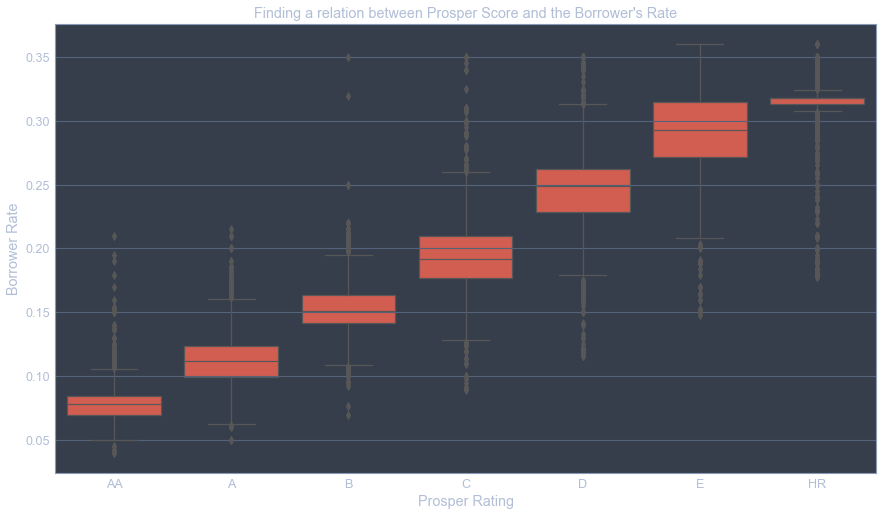

```python
# to find the relation between prosper score and the borrower's rate

# plotting a box graph
plt.figure(figsize = [14.70, 8.27])
plt.subplots_adjust(wspace = 0.85)
result = df.groupby(["ProsperRating (Alpha)"])['BorrowerRate'].aggregate(np.median).reset_index().sort_values('BorrowerRate')
sb.boxplot(x = df['ProsperRating (Alpha)'], y = df['BorrowerRate'], order=result['ProsperRating (Alpha)'], color = sb.color_palette()[9]);
plt.xlabel('Prosper Rating')
plt.ylabel('Borrower Rate')
plt.title('Finding a relation between Prosper Score and the Borrower\'s Rate');
```

With this graph we can say that your Prosper Rating is a big determining factor in getting you a borrower's rate

### Prosper Score vs. Income Range

[figure not shown]

```python
#prosper score vs income range


# income categories in order
income_order = ['Not employed', '$0',  '$1-24,999','$25,000-49,999', '$50,000-74,999' , '$75,000-99,999', '$100,000+']
plt.figure(figsize=(14.70, 8.27))
ax = sb.countplot(data = df, x = 'ProsperRating (Alpha)', order=result['ProsperRating (Alpha)'], hue = 'IncomeRange', hue_order = income_order)
ax.legend(loc = 'best', framealpha = 1, title = 'Gender', fontsize=12);
plt.xlabel('Prosper Score',fontsize= 15)
plt.ylabel('Count',fontsize= 15)
plt.title('ProsperScore vs. IncomeRange',fontsize= 20);
```

People with income of more than 100,000 are the ones with the Highest Prosper Score. $ 50K to $ 75K are the one who get a rating of A, B or C the most and the prosper score gets worse as the income goes lower.

### Borrower's Rate vs. Prosper Score vs. Income Range

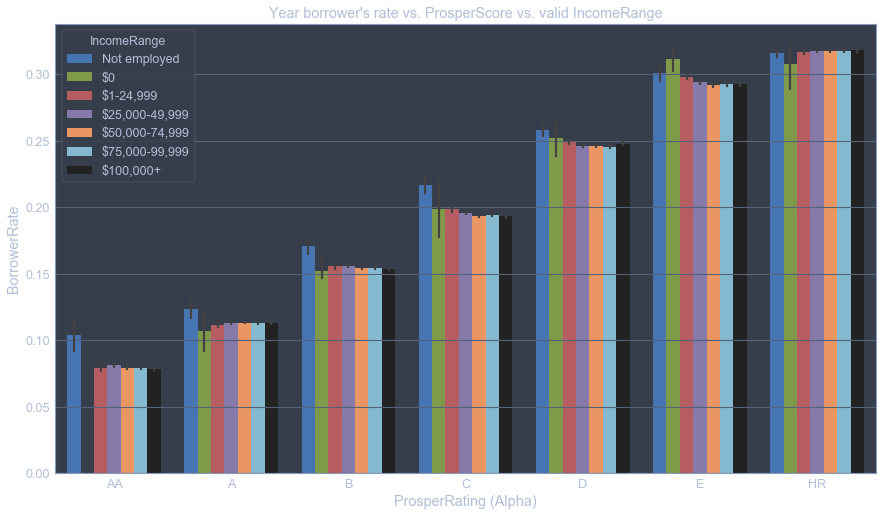

```python
# plotting a relation between borrower's rate vs. prosper score vs. income range

# income categories in order
income_order = ['Not employed', '$0',  '$1-24,999','$25,000-49,999', '$50,000-74,999' , '$75,000-99,999', '$100,000+']
plt.figure(figsize=[14.70, 8.27]);
sb.barplot(data = df, x = 'ProsperRating (Alpha)', y = 'BorrowerRate', order=result['ProsperRating (Alpha)'], hue = 'IncomeRange', hue_order = income_order);
plt.title('Year borrower\'s rate vs. ProsperScore vs. valid IncomeRange');
```